# prenoms_dplyr_clean_data_if-at-all_en

Please, submit your work in shape of a zipped folder containing an RStudio project to xhec2018@thinkr.fr

Deadline : 4th november, 11:00 PM

The name of the project should be ???dplyr_firstname_lastname???.

The project must contain a .Rmd file and the corresponding rendered .html file. Packages should be loaded at the top of the .Rmd file.

## Warm-up

### Make sure you’ve installed {dplyr} >= 0.7 and {prenoms} package

```r
# Installing {dplyr} and {prenoms} if these packages are not installed yet or if installed but in an older version, using "require".
if (!require(prenoms)) install.packages('prenoms')
if (!require(dplyr) | packageVersion("dplyr")<0.7) install.packages('dplyr')
#Now both packages should be installed in a recent enough version
```

### Load here `{dplyr}`, `{prenoms}` and any other needed package

```r
library(dplyr)
library(prenoms)
library(stringr) #needed for Q1 of "Elementary and College Schools" part
library(readxl) #needed for Q1 of "Facts observed by the police services and national gendarmerie units by department"
library(tidyr) #needed for Q1 of "Facts observed by the police services and national gendarmerie units by department"
library(sf) #needed for bonus question
```

```r
library(ggplot2) #needed for bonus question
```

### Import

#### prenomsdataset

Using `data(prenoms)` load `prenoms` dataset from `{prenoms}` package.

```r
data(prenoms)
```

What kind of object is `prenoms` ?

```r
class(prenoms)
```

```
## [1] "tbl_df"     "tbl"        "data.frame"
```

```r
# prenoms is a special type of data frame, it is a tibble.
```

Explore the database using the ‘5-functions-to-always-run-on-a-database’

```r
prenoms %>% dim()
```

```
## [1] 3712763       6
```

```r
prenoms %>% names()
```

```
## [1] "year" "sex"  "name" "n"    "dpt"  "prop"
```

```r
prenoms %>% head()
```

```
## # A tibble: 6 x 6
##    year sex   name              n dpt      prop
##   <int> <chr> <chr>         <int> <chr>   <dbl>
## 1  1900 F     "Ad\u00e8le"      5 01    0.00158
## 2  1900 F     Adrienne          9 01    0.00284
## 3  1900 F     "Aim\u00e9e"      7 01    0.00221
## 4  1900 F     Alice            24 01    0.00757
## 5  1900 F     Alphonsine        5 01    0.00158
## 6  1900 F     "Am\u00e9lie"     8 01    0.00252
```

```r
prenoms %>% summary()
```

```
##       year          sex                name                 n
##  Min.   :1900   Length:3712763     Length:3712763     Min.   :   0.00
##  1st Qu.:1945   Class :character   Class :character   1st Qu.:   4.00
##  Median :1976   Mode  :character   Mode  :character   Median :   7.00
##  Mean   :1970                                         Mean   :  20.11
##  3rd Qu.:1999                                         3rd Qu.:  17.00
##  Max.   :2017                                         Max.   :4055.00
##      dpt                 prop
##  Length:3712763     Min.   :0.0000000
##  Class :character   1st Qu.:0.0004935
##  Mode  :character   Median :0.0012043
##                     Mean   :0.0031782
##                     3rd Qu.:0.0032994
##                     Max.   :0.3101177
```

```r
# I used the 'View' function to have a look at the tibble, but removed it because it prevents the file from knitting.

# Setting UTF-8 to account for accents
Sys.setlocale(locale = "en_us.UTF-8")
```

```
## [1] "en_us.UTF-8/en_us.UTF-8/en_us.UTF-8/C/en_us.UTF-8/C"
```

Using `glimpse`, have a look at `prenoms`’s structure.

```r
prenoms %>% glimpse()
```

```
## Observations: 3,712,763
## Variables: 6
## $ year <int> 1900, 1900, 1900, 1900, 1900, 1900, 1900, 1900, 1900, 190...
## $ sex  <chr> "F", "F", "F", "F", "F", "F", "F", "F", "F", "F", "F", "F...
## $ name <chr> "Adèle", "Adrienne", "Aimée", "Alice", "Alphonsine", "Amé...
## $ n    <int> 5, 9, 7, 24, 5, 8, 5, 6, 21, 12, 21, 6, 5, 5, 17, 3, 5, 1...
## $ dpt  <chr> "01", "01", "01", "01", "01", "01", "01", "01", "01", "01...
## $ prop <dbl> 0.0015777848, 0.0028400126, 0.0022088987, 0.0075733670, 0...
```

#### Regions, departements and surfaces

Load the “dpt_data_modif.csv” dataset from IGN (French public state administrative establishment founded in 1940[1] to produce and maintain geographical information for France and its overseas departments and territories) using the appropriate function. Data have been prepared for you: the surface of departement has been calculated and spatial data removed.

```r
# Reading the csv file
dpt_data_modif <- read.csv("data/dpt_data_modif.csv")
# Displaying the first rows
dpt_data_modif %>% head()
```

[output not shown]

#### Elementary and college schools

We also fetched for you on [data.gouv.fr](https://www.data.gouv.fr/fr/datasets/adresse-et-geolocalisation-des-etablissements-denseignement-du-premier-et-second-degres/#_) the addresses of “primary and secondary schools, the administrative structures of the Ministry of National Education. Public and private sectors.”

1. Data preprocessing
   - Import the csv file : “DEPP-etab-1D2D.csv” and name it “depp_orig”
     - Encoding is `"latin1"`
   - Transform zip code (“code_postal_uai”) into 5 characters with zeros
   - Extract department numbers (“dpt”) starting from column “code_postal_uai”
   - Save the modifications into “depp_modif.csv”

```r
# Reading the csv file
depp_orig <- read.csv2("data/DEPP-etab-1D2D.csv", encoding = "latin1")
# Changing the formatting of zip codes and extracting department numbers
depp_modif <- depp_orig %>% mutate(code_postal_uai = sprintf("%05d",code_postal_uai)) %>%
  mutate(dpt = str_sub(code_postal_uai, 1, 2))
# Displaying the first rows
depp_modif %>% head()
```

```
##   numero_uai                  appellation_officielle
## 1   0010001W    Lycée professionnel Alexandre Bérard
## 2   0010002X                   Collège Saint-Exupéry
## 3   0010005A                  Collège Roger Poulnard
## 4   0010006B          Lycée polyvalent Saint-Exupéry
## 5   0010008D                   Collège Saint-Exupéry
## 6   0010010F Lycée général et technologique du Bugey
##          denomination_principale    patronyme_uai
## 1           LP LYCEE DES METIERS ALEXANDRE BERARD
## 2                        COLLEGE    SAINT-EXUPERY
## 3                        COLLEGE   ROGER POULNARD
## 4          LPO LYCEE DES METIERS    SAINT-EXUPERY
## 5                        COLLEGE    SAINT-EXUPERY
## 6 LYCEE GENERAL ET TECHNOLOGIQUE         DU BUGEY
##   secteur_public_prive_libe               adresse_uai lieu_dit_uai
```

[output cut: 27 more lines]

```r
# Saving the modifications in a new csv file
write.csv(depp_modif, "data/depp_modif_iva.csv")
```

2. Read the pre-processed “depp_modif.csv” file

```r
# Reading the file we just created
read.csv("data/depp_modif_iva.csv", row.names = 1)
# Reading the pre-processed file we were given
read.csv("data/depp_modif.csv")

# The chunk is silent because otherwise the html file would be too heavy
# I checked that both files can be used in the same way in the following analyses
```

#### Facts observed by the police services and national gendarmerie units by department

We also gathered data from [data.gouv.fr](https://www.data.gouv.fr/fr/datasets/faits-constates-par-index-par-departement-et-par-annee/#_) concerning “all the facts observed by the police services and national gendarmerie units by department from 1996 to 2011”

1. Data preprocessing
   - Import Excel sheet “2010” from “faitsconstatespardepartementde2002-a-2011.xls” file
     - *beware of the original formatting*
   - Copy it into “faits_2010_modif” in order to make some modifications:
     - Delete Excel calculations:
       - `Tout_d??partement`, `Tout_index`
     - Transform in long format using `gather`
       - 4 columns : Index, Libell??, dpt, nombre
     - save the dataframe into a csv file “faits_2010_modif.csv”

```r
# Reading the csv file
faits_2010 <- read_excel("data/faitsconstatespardepartementde2002-a-2011.xls", sheet = "2010", skip = 1) #Using Skip to have the right variable names and correct the original formatting (skipping 1 row at least before reading anything)
# Displaying the first rows
head(faits_2010)
```

```
## # A tibble: 6 x 100
##   Index Libellé `Tout départeme…  `01`  `02`  `03`  `04`  `05`  `06`  `07`
##   <dbl> <chr>              <dbl> <dbl> <dbl> <dbl> <dbl> <dbl> <dbl> <dbl>
## 1    NA Tout i…          3447903 22615 24052 11653  7035  5303 93308 11011
## 2     1 Règlem…               43     0     0     0     0     0     3     0
## 3     2 Homici…               36     0     0     0     0     0     1     0
## 4     3 Homici…              550     6     7     2     3     3    27     5
## 5     4 Tentat…               56     1     0     1     0     0     1     0
## 6     5 Tentat…             1015     9     6     5     0     0    22     4
## # ... with 90 more variables: `08` <dbl>, `09` <dbl>, `10` <dbl>,
## #   `11` <dbl>, `12` <dbl>, `13` <dbl>, `14` <dbl>, `15` <dbl>,
## #   `16` <dbl>, `17` <dbl>, `18` <dbl>, `19` <dbl>, `21` <dbl>,
## #   `22` <dbl>, `23` <dbl>, `24` <dbl>, `25` <dbl>, `26` <dbl>,
## #   `27` <dbl>, `28` <dbl>, `29` <dbl>, `2A` <dbl>, `2B` <dbl>,
## #   `30` <dbl>, `31` <dbl>, `32` <dbl>, `33` <dbl>, `34` <dbl>,
## #   `35` <dbl>, `36` <dbl>, `37` <dbl>, `38` <dbl>, `39` <dbl>,
## #   `40` <dbl>, `41` <dbl>, `42` <dbl>, `43` <dbl>, `44` <dbl>,
## #   `45` <dbl>, `46` <dbl>, `47` <dbl>, `48` <dbl>, `49` <dbl>,
## #   `50` <dbl>, `51` <dbl>, `52` <dbl>, `53` <dbl>, `54` <dbl>,
## #   `55` <dbl>, `56` <dbl>, `57` <dbl>, `58` <dbl>, `59` <dbl>,
## #   `60` <dbl>, `61` <dbl>, `62` <dbl>, `63` <dbl>, `64` <dbl>,
## #   `65` <dbl>, `66` <dbl>, `67` <dbl>, `68` <dbl>, `69` <dbl>,
## #   `70` <dbl>, `71` <dbl>, `72` <dbl>, `73` <dbl>, `74` <dbl>,
## #   `75` <dbl>, `76` <dbl>, `77` <dbl>, `78` <dbl>, `79` <dbl>,
## #   `80` <dbl>, `81` <dbl>, `82` <dbl>, `83` <dbl>, `84` <dbl>,
## #   `85` <dbl>, `86` <dbl>, `87` <dbl>, `88` <dbl>, `89` <dbl>,
## #   `90` <dbl>, `91` <dbl>, `92` <dbl>, `93` <dbl>, `94` <dbl>,
## #   `95` <dbl>, `Service à compétence national` <dbl>
```

```r
# Removing Excel calculations and transforming in long format using 'gather'
faits_2010_modif <- faits_2010 %>% dplyr::select(-"Tout département") %>%
  filter(Libellé != "Tout index") %>%
  gather(key = "dpt", value = "nombre", 3:99)
# Displaying the first rows again
head(faits_2010_modif)
```

```
## # A tibble: 6 x 4
##   Index Libellé                                               dpt   nombre
##   <dbl> <chr>                                                 <chr>  <dbl>
## 1     1 Règlements de compte entre malfaiteurs                01         0
## 2     2 Homicides pour voler et à l'occasion de vols          01         0
## 3     3 Homicides pour d'autres motifs                        01         6
## 4     4 Tentatives d'homicides pour voler et à l'occasion de… 01         1
## 5     5 Tentatives homicides pour d'autres motifs             01         9
## 6     6 Coups et blessures volontaires suivis de mort         01         1
```

```r
# Saving in a new csv file
write.csv(faits_2010_modif, "data/faits_2010_modif_iva.csv")
```

2. Read preprocessed file “faits_2010_modif.csv”

```r
# Reading the file we just created
read.csv("data/faits_2010_modif_iva.csv", row.names = 1)
# Reading the pre-processed file we were sent
read.csv("data/faits_2010_modif.csv")

#The chunk is silent because otherwise the html file would be too heavy
# I checked that both files can be used in the same way in the following analyses
```

## Analyses

Some assumptions to do the exercise:

- every child born in a department stays into that department until the end of college
- every children between 11 and 14 years old is in a college
- the number of college is constant between 2010 and 2016
- College “?? ouvrir” (i.e. “to be open”) do not have children. Others have.

### Filter datasets to Metropolitan France

Datasets to be filtered: `prenoms`, `depp_modif`, `faits_2010_modif`, `dpt_data_modif`

- Department named “2A” and “2B” should be merged to “20”
- We only work with data in Metropolitan France, which means for “dpt” between `01` and `95` included. Others needs to be filtered.

```r
# Checking what departments we have in each file (hidden results)
prenoms %>% distinct(dpt)
depp_modif %>% distinct(dpt)
faits_2010_modif %>% distinct(dpt)
dpt_data_modif %>% distinct(CODE_DEPT)
```

```r
# Turning 2A and 2B into 20 and getting rid of everything that is not between 01 and 95

# prenoms has 2A and 2B and dpts > 95
prenoms_metropolitan <- prenoms %>% mutate(dpt = case_when(
  dpt %in% c("2A","2B") ~ "20",
  TRUE ~ as.character(dpt))) %>%
  filter(dpt <= 95)

# depp_modif has 00 and > 95
depp_modif_metropolitan <- depp_modif %>%
  filter(dpt != "00" & dpt <= 95)

# faits_2010_modif has 2A, 2B and Service à compétence national
faits_2010_modif_metropolitan <- faits_2010_modif %>%
  mutate(dpt = case_when(
  dpt %in% c("2A","2B") ~ "20",
  TRUE ~ dpt)) %>%
  filter(dpt != "Service à compétence national")

#dpt_data_modif has 2A and 2B
dpt_data_modif_metropolitan <- dpt_data_modif %>%
  mutate(CODE_DEPT = case_when(
  CODE_DEPT %in% c("2A","2B") ~ "20",
  TRUE ~ as.character(CODE_DEPT)))
```

### National average number of children per college in 2010 ?

```r
# Pulling the total number of children in colleges (born between 1996 and 1999 so as to be 11 to 14 in 2010)
children_in_college <- prenoms_metropolitan %>% filter(year %in% c(1996:1999)) %>%
  summarise(children_in_college = sum(n)) %>%
  pull(children_in_college)

# Pulling the total number colleges opened
colleges <- depp_modif_metropolitan %>% filter(nature_uai_libe %in% c("Collège", "Collège spécialisé", "Collège climatique") & etat_etablissement != 3) %>%
  summarise(colleges = n()) %>%
  pull(colleges)

# Dividing the total number of children in colleges by the total number of colleges and displaying the result
print(average_children_per_college <- children_in_college / colleges)
```

```
## [1] 349.0387
```

### Average number of children per college in 2010 in each department?

- Arrange departments according to the calculated average in descending order

```r
# Getting the number of children in colleges in each department
children_in_college_dpt <- prenoms_metropolitan %>%
  filter(year %in% c(1996:1999)) %>%
  group_by(dpt) %>%
  summarise(children_in_college = sum(n))

# Getting the number of colleges in each department
colleges_dpt <- depp_modif_metropolitan %>%
  filter(nature_uai_libe %in% c("Collège","Collège spécialisé","Collège climatique") & etat_etablissement !=3) %>%
  group_by (dpt) %>%
  summarise(colleges = n())

# Joining both tables and calculating the average number of children per college in 2010 in each department by dividing
average_children_per_college_dpt <- full_join(children_in_college_dpt, colleges_dpt) %>%
  mutate(average_children_per_college = children_in_college / colleges) %>%
  dplyr::select(dpt, average_children_per_college) %>%
  arrange(desc(average_children_per_college))
# Displaying the result
average_children_per_college_dpt
```

```
## # A tibble: 95 x 2
##    dpt   average_children_per_college
##    <chr>                        <dbl>
##  1 75                            721.
##  2 92                            608.
##  3 69                            517.
##  4 59                            478.
##  5 76                            450.
##  6 84                            429.
##  7 42                            416.
##  8 51                            414.
##  9 74                            413.
## 10 68                            411.
## # ... with 85 more rows
```

### Number of Facts observed by the police services in 2010 per department ?

```r
# Calculating the number of facts by department
faits_2010_dpt <- faits_2010_modif_metropolitan %>%
  group_by(dpt) %>%
  summarise(nb_faits = sum(nombre)) %>%
  arrange(desc(nb_faits))

# Displaying the result
faits_2010_dpt
```

```
## # A tibble: 95 x 2
##    dpt   nb_faits
##    <chr>    <dbl>
##  1 75      238856
##  2 13      172445
##  3 59      166565
##  4 93      142798
##  5 69      115632
##  6 92       96520
##  7 06       93308
##  8 95       92392
##  9 94       90376
## 10 33       85153
## # ... with 85 more rows
```

### Number of children born, number of colleges and facts related by the police services per department in 2010 ?

- Group all information in the same table
- Arrange by descending order of children, schools and facts

```r
# Calculating the number of children born in 2010 by department
children_2010 <- prenoms_metropolitan %>%
  filter(year == "2010") %>%
  group_by(dpt) %>%
  summarise(children_born = sum(n))

# Joining this table with the table indicating the number of colleges by department
children_born_and_colleges_2010 <- full_join(children_2010 , colleges_dpt)
# Joining this table with the table indicating the number of facts observed, under the name "master_table_2010"
master_table_2010 <- full_join(children_born_and_colleges_2010, faits_2010_dpt) %>%
  arrange(desc(children_born), desc(colleges), desc(nb_faits))
# Displaying the result
master_table_2010
```

```
## # A tibble: 95 x 4
##    dpt   children_born colleges nb_faits
##    <chr>         <int>    <int>    <dbl>
##  1 75            35795      192   238856
##  2 59            33771      289   166565
##  3 69            23073      170   115632
##  4 92            22114      139    96520
##  5 13            21893      194   172445
##  6 93            16082      157   142798
##  7 62            14983      160    73918
##  8 76            14878      133    66765
##  9 44            14539      145    71222
## 10 94            14355      138    90376
## # ... with 85 more rows
```

### Number of children born, number of colleges and facts related by the police services per km?? in 2010 by department?

```r
# Getting the surface of each department in km2
km2_dpt <- dpt_data_modif_metropolitan %>%
  mutate(km2 = surface_m / 1000000) %>%
  group_by(CODE_DEPT, CODE_REG, NOM_REG) %>%
  summarise(surface_km2 = sum(km2))

# Joining this table with our master_table_2010 and divinding each previous column by the surface in km2
master_table_2010_km2 <- full_join(master_table_2010,km2_dpt, by = c("dpt" = "CODE_DEPT")) %>%
  mutate(children_born_km2 = children_born / surface_km2) %>%
  mutate(colleges_km2 = colleges / surface_km2) %>%
  mutate(nb_faits_km2 = nb_faits / surface_km2) %>%
  arrange(desc(children_born_km2), desc(colleges_km2), desc(nb_faits_km2))

# Displaying the result
print(master_table_2010_km2 %>% dplyr::select(dpt, children_born_km2, colleges_km2, nb_faits_km2))
```

```
## # A tibble: 95 x 4
##    dpt   children_born_km2 colleges_km2 nb_faits_km2
##    <chr>             <dbl>        <dbl>        <dbl>
##  1 75               338.         1.81         2254.
##  2 92               126.         0.792         550.
##  3 93                67.8        0.661         602.
##  4 94                58.8        0.565         370.
##  5 95                10.9        0.113          73.7
##  6 69                 7.09       0.0523         35.5
##  7 91                 6.29       0.0676         38.5
##  8 78                 5.99       0.0655         36.5
##  9 59                 5.86       0.0501         28.9
## 10 13                 4.30       0.0381         33.9
## # ... with 85 more rows
```

### Is there a correlation between the number of birth and the number of facts related by the police per km?? in 2010 ?

```r
# We use the Pearson method, which is the more common, because we can infer that both samples follow a gaussian distribution
cor.test(master_table_2010_km2$children_born_km2, master_table_2010_km2$nb_faits_km2, method = "pearson")
```

```
##
##  Pearson's product-moment correlation
##
## data:  master_table_2010_km2$children_born_km2 and master_table_2010_km2$nb_faits_km2
## t = 71.32, df = 93, p-value < 2.2e-16
## alternative hypothesis: true correlation is not equal to 0
## 95 percent confidence interval:
##  0.9864597 0.9939980
## sample estimates:
##       cor
## 0.9909816
```

```r
# We observe a very high correlation: 0.99. The 95 % confidence interval is rather small so we are very confident in this high correlation.
```

### What is the mean regional density (in number/km??) of the 15 most given first names in France ?

- Filter the 15 most given first names in France
- Create a unique wide table with the department as observations and the 15 most given names in columns (as variables): the count is at the row-column intersection
- merge with the surface department infos
- Compute the region surface and the density of names by region (e.g. number of people named “Bob”, “Anna”, … by km?? of each region)
  - Region name is stored in variable `NOM_REG`. (There are multiple departments in each region)

```r
# Filtering the 15 most given first names in France (inference: we don't take genders into account)
fifteen_prenoms_metropolitan <- prenoms_metropolitan %>%
  filter(year == "2010") %>%
  group_by(name) %>%
  summarise(total = sum(n)) %>%
  top_n(15, total) %>%
  arrange(desc(total))

# Creating a table with the department as observations and the 15 most given names in columns (as variables): the count is at the row-column intersection
density_table_dpt <- prenoms_metropolitan %>%
  filter(name %in% fifteen_prenoms_metropolitan$name) %>%
  filter(year == "2010") %>%
  dplyr::select(-sex, -prop, -year) %>%
  group_by(name, dpt) %>%
  summarise(total = sum(n)) %>%
  spread(key = "name", value = "total")

# Replacing all the NA by 0 to ease calculation
density_table_dpt[is.na(density_table_dpt)] <- 0

# Merging with the surface dpt info and computing the region surface and the total number of names by region
density_table_region <- full_join(density_table_dpt, km2_dpt, by = c("dpt" = "CODE_DEPT")) %>%
  group_by(NOM_REG, CODE_REG) %>%
  summarise_if(is.numeric,sum)

# Computing the density of names by km2 by region
density_table_region_km2 <- density_table_region %>%
  mutate_at(vars(3:17), funs(. / surface_km2)) %>%
  dplyr::select(-surface_km2)

# Displaying the result
density_table_region_km2
```

```
## # A tibble: 13 x 17
## # Groups:   NOM_REG [13]
##    NOM_REG CODE_REG  Arthur Camille    Emma    Enzo   Ethan Gabriel    Hugo
##    <fct>      <int>   <dbl>   <dbl>   <dbl>   <dbl>   <dbl>   <dbl>   <dbl>
##  1 ALSACE…       44 6.34e-3 0.00704 0.0109  0.00901 5.91e-3 0.00551 7.54e-3
##  2 AQUITA…       75 4.50e-3 0.00485 0.00631 0.00657 4.66e-3 0.00395 4.77e-3
##  3 AUVERG…       84 7.18e-3 0.00846 0.0107  0.00812 6.10e-3 0.00682 8.53e-3
##  4 BOURGO…       27 4.00e-3 0.00381 0.00573 0.00615 3.69e-3 0.00265 4.40e-3
##  5 BRETAG…       53 8.62e-3 0.00789 0.0105  0.0109  9.42e-3 0.00654 8.76e-3
##  6 CENTRE…       24 3.98e-3 0.00524 0.00613 0.00654 4.74e-3 0.00471 4.36e-3
##  7 CORSE         94 4.57e-4 0.00274 0.00320 0.00183 2.28e-4 0.00365 6.85e-4
##  8 ILE-DE…       11 6.91e-2 0.0758  0.0970  0.0751  6.74e-2 0.0938  6.03e-2
##  9 LANGUE…       76 4.07e-3 0.00439 0.00676 0.00654 4.51e-3 0.00523 5.20e-3
## 10 NORD-P…       32 1.39e-2 0.0162  0.0212  0.0223  1.71e-2 0.0122  1.73e-2
## 11 NORMAN…       28 6.94e-3 0.00823 0.0120  0.0133  7.74e-3 0.00704 8.86e-3
## 12 PAYS D…       52 7.79e-3 0.0117  0.0112  0.0123  7.72e-3 0.00674 9.33e-3
## 13 PROVEN…       93 6.91e-3 0.00976 0.0149  0.0117  1.05e-2 0.0119  9.25e-3
## # ... with 8 more variables: Jade <dbl>, Jules <dbl>, Lola <dbl>,
## #   Louis <dbl>, Lucas <dbl>, Manon <dbl>, Mathis <dbl>, Nathan <dbl>
```

#### Bonus question : map the mean regional density (in number/km??) of the 15 most given first names in France

- Use the “department” shapefile to cross information and map data
  - Region name is stored in variable `NOM_REG`. (There are multiple departments in each region)

```r
# Creating a department map using the "department" shapefile
map_l93 <- st_read(
  "data/departements/DEPARTEMENT.shp"
  , quiet = FALSE, stringsAsFactors = FALSE)
# Merging departments into regions
map_regions_l93 <-  map_l93 %>%
  mutate(CODE_REG = as.integer(CODE_REG)) %>%
  group_by(CODE_REG, NOM_REG) %>%
  summarize()
glimpse(map_regions_l93)
```

```
## Observations: 13
## Variables: 3
## $ CODE_REG <int> 11, 24, 27, 28, 32, 44, 52, 53, 75, 76, 84, 93, 94
## $ NOM_REG  <chr> "ILE-DE-FRANCE", "CENTRE-VAL DE LOIRE", "BOURGOGNE-FR...
## $ geometry <GEOMETRY [m]> POLYGON ((670084.3 6886723,..., POLYGON ((69...
```

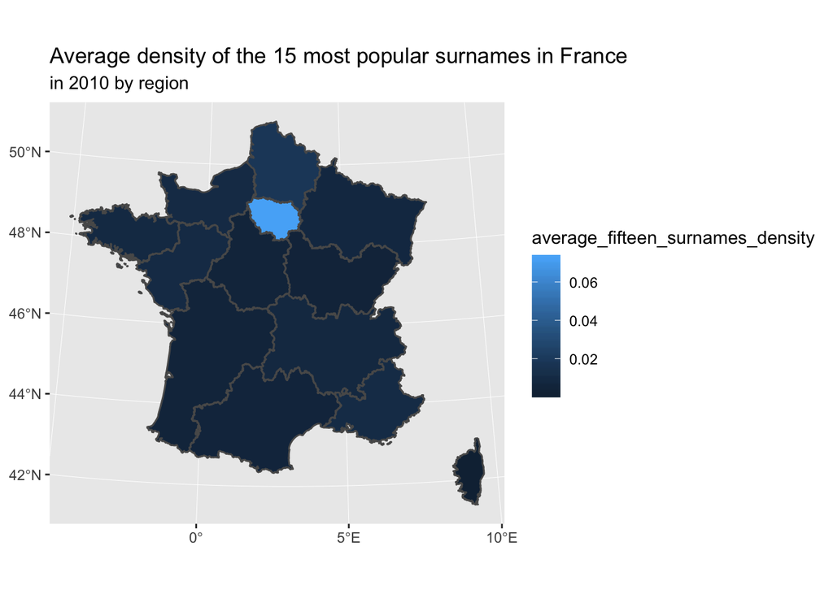

```r
# Merging with densities and creating an average of the 15 most popular surnames densities
map_regions_density_l93 <- full_join(map_regions_l93, density_table_region_km2, by = "CODE_REG") %>%
  mutate(average_fifteen_surnames_density = (Arthur + Nathan + Lucas + Emma + Enzo + Manon + Lola + Louis + Camille + Jade + Hugo + Gabriel + Ethan + Jules + Mathis)/ 15)

# Mapping regions with different colors according to the average density for the 15 most popular surnames
ggplot(map_regions_density_l93) +
  geom_sf(aes(fill = average_fifteen_surnames_density)) +
  coord_sf(crs = st_crs(map_regions_density_l93)) +
  ggtitle("Average density of the 15 most popular surnames in France", subtitle = "in 2010 by region")
```

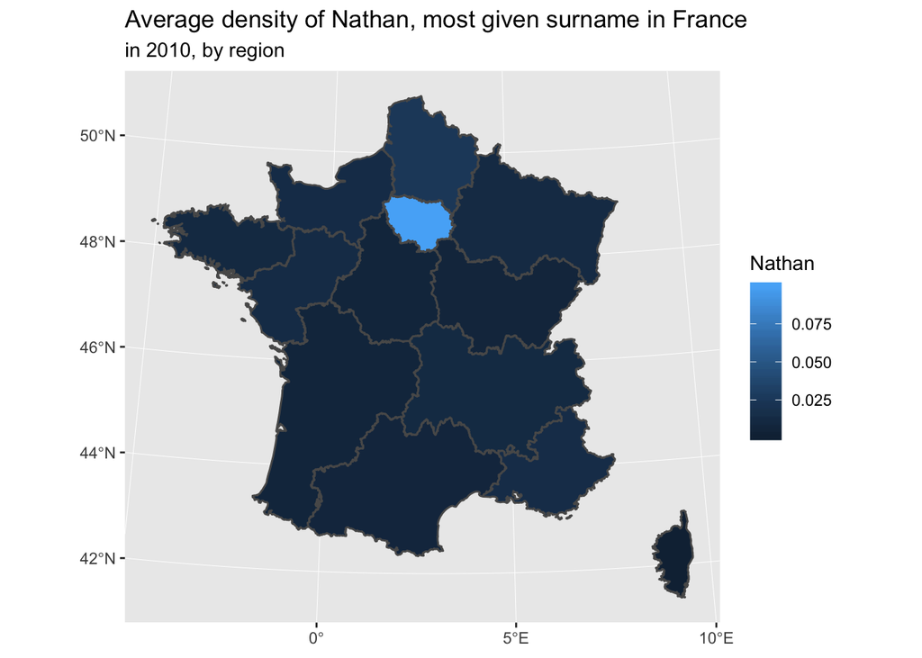

```r
# Mapping reginos with different colors according to the density for the most popular surname, Nathan
ggplot(map_regions_density_l93) +
  geom_sf(aes(fill = Nathan)) +
  coord_sf(crs = st_crs(map_regions_density_l93)) +
  ggtitle("Average density of Nathan, most given surname in France", subtitle = "in 2010, by region")
```